# **Branchwise rates results**

[Hummingbird song evolution](https://github.com/maRce10/hummingbird_song_evolution)

[Marcelo Araya-Salas, PhD](http://marceloarayasalas.weebly.com/)

19-04-2020

### Load packages

```r
rm(list = ls())

# unload all non-based packages
out <- sapply(paste('package:', names(sessionInfo()$otherPkgs), sep = ""), function(x) try(detach(x, unload = FALSE, character.only = TRUE), silent = T))

## add 'developer/' to packages to be installed from github
x <- c(
  "ggtree",
  "ape",
  "viridis",
  "readxl",
  "ggplot2",
  "leaflet",
   "phangorn",
   "parallel",
   "pbapply",
    "cowplot",
    "coda"
    )

out <- lapply(x, function(y) {
  # get pakage name
  pkg <- strsplit(y, "/")[[1]]
  pkg <- pkg[length(pkg)]

  # check if installed, if not then install
  if (!pkg %in% installed.packages()[, "Package"])  {
  if (grepl("/", y))
  devtools::install_github(y, force = TRUE)
  else
  install.packages(y)
  }

  # load package
  try(require(pkg, character.only = T), silent = T)
})

knitr::opts_knit$set(root.dir = normalizePath(".."))

knitr::opts_chunk$set(dpi = 58, fig.width = 20, fig.height = 15)
```

### Set parameters, read data and make base ggtree plots

```r
#colors for plots
cols <- viridis(10, alpha = 0.7)

# font size of clade labels
fontsize <- 13

# edge width
lwd <- 2

# functions to get descendant nodes
select.tip.or.node <- function(element, tree) {
    ifelse(element < Ntip(tree)+1, tree$tip.label[element], tree$node.label[element-Ntip(tree)])
}

get_edge_table <- function(phy){

    phy$node.label <- paste0("node", seq_len(Ntip(phy)))

    edge_table <- data.frame(
                "parent" = phy$edge[,1],
                "par.name" = sapply(phy$edge[,1], select.tip.or.node, tree = phy),
                "child" = phy$edge[,2],
                "chi.name" = sapply(phy$edge[,2], select.tip.or.node, tree = phy),
                length = phy$edge.length
                )
return(edge_table)
}

# make any numeric variable within a specific range
range01 <- function(x, min = 0, max = 1){
  x <- x + min(x)
  x <- (x-min(x))/(max(x)-min(x))

  x <- x * (max - min)

  x <- x + min

  return(x)
  }

# ggplot2 theme
theme_set(theme_classic(base_size = 14,base_family = "Arial"))

# main tree
phy <- read.nexus("data/processed/trees/ConsensoBayesTraits.trees")

phy <- rotateConstr(phy = phy, constraint = rev(phy$tip))

phy <- ladderize(phy)


# read branchwise rates
xls <- list.files(path = "./output/bayestraits", full.names = TRUE, pattern = "\\.xls")

# get branchwise rates into a list
branchwise_rates <- lapply(xls, function(x) {

  X <- as.data.frame(read_excel(x))

  X$variable <- gsub("BranchWiseRate_|BranchWiseRates_|.xlsx", "", basename(x))

  # get the ones with r == 1 (r != 1 means significantly different than background rate)
  X$log.r <- log(X$`Median Scalar (r)` + 1)

  names(X)[7] <- "Optimized Rate (r * backgroundrate)"

  domain <- range(0, 1)


  pal_fun <- colorNumeric(palette = "viridis", domain = domain, reverse = TRUE)

    # previewColors(pal_fun, seq(min(domain), max(domain), length.out = 30))

  X$r.for.color <- NA

  # color range for low rates
  X$r.for.color[X$`Optimized Rate (r * backgroundrate)`< X$`Background Rate (per million year)`] <- range01(X$log.r[X$`Optimized Rate (r * backgroundrate)`< X$`Background Rate (per million year)`], min = 0.7, max = 0.8)

  # color range for high rates
  X$r.for.color[X$`Optimized Rate (r * backgroundrate)`> X$`Background Rate (per million year)`] <- range01(X$log.r[X$`Optimized Rate (r * backgroundrate)`> X$`Background Rate (per million year)`], min = 0.1, max = 0.5)

  X$rate.color <- "gray"

  X$rate.color <- pal_fun(X$r.for.color)

  # get gray the ones with less than 95% of time under background rate
  X$rate.color[X$`Percentage time scaled`< 95] <- "gray"

  return(X)
  })

# names(branchwise_rates) <-  gsub("BranchWiseRate_|BranchWiseRates_|.xlsx", "", basename(xls))

names(branchwise_rates) <- c("Sequence complexity", "# of element types", "Acoustic space", "Between song variation")

# get background rates per parameter
background_rates <- sapply(branchwise_rates, function(x)
  mean(x$`Background Rate (per million year)`))

log_background_rates <- log(background_rates + 1)


# put branchwise rates in a single data frame

phy.btw.sng.vr <- drop.tip(phy, tip = setdiff(phy$tip.label, branchwise_rates$`Between song variation`$`Taxa List`[branchwise_rates$`Between song variation`$`No Taxa` == 1]))

# ggplot2 theme
theme_set(theme_tree2(base_size = 14,base_family = "Arial"))

# song acoustic parameters
song.acoust.param <- read.csv("data/processed/acoustic/Song parameters nightjars swifts and hummingbirds.csv", stringsAsFactors = FALSE)

song.acoust.param$species <- song.acoust.param$species_uscr

sp.clade <- song.acoust.param[!duplicated(song.acoust.param$species) , c("species", "Clade")]

# rename hummers
sp.clade$maj.clade <- ifelse(sp.clade$Clade %in% c("Nightjars", "Swifts"), sp.clade$Clade, "Hummingbirds")

# all clades Except for Patagona
all.clade.nodes <- sapply(c("Emeralds", "Coquettes", "Swifts", "Brilliants", "Mangoes", "Hermits", "Nightjars", "Bees", "Mtn. Gems", "Topazes", "Hummingbirds"), function(x) getMRCA(phy = phy, tip = if(x == "Hummingbirds") sp.clade$species[!sp.clade$Clade %in% c("Swifts", "Nightjars")] else sp.clade$species[sp.clade$Clade == x]))


# 3 major clades
maj.clade.nodes <- sapply(c("Swifts", "Nightjars", "Hummingbirds"), function(x) getMRCA(phy = phy, tip = if(x == "Hummingbirds") sp.clade$species[!sp.clade$Clade %in% c("Swifts", "Nightjars")] else sp.clade$species[sp.clade$Clade == x]))

sp.clade.bsv  <- sp.clade[sp.clade$species %in%  phy.btw.sng.vr$tip.label, ]

# 3 major clades for between song variation
maj.clade.nodes.bsv <- sapply(c("Swifts", "Nightjars", "Hummingbirds"), function(x) getMRCA(phy = phy.btw.sng.vr, tip = if(x == "Hummingbirds") sp.clade.bsv$species[!sp.clade.bsv$Clade %in% c("Swifts", "Nightjars")] else sp.clade.bsv$species[sp.clade.bsv$Clade == x]))

# all clades Except for Patagona for between song variation
all.clade.nodes.bsv <- sapply(c("Emeralds", "Coquettes", "Swifts", "Brilliants", "Mangoes", "Hermits", "Nightjars", "Bees", "Mtn. Gems", "Topazes", "Hummingbirds"), function(x) getMRCA(phy = phy.btw.sng.vr, tip = if(x == "Hummingbirds") sp.clade.bsv$species[!sp.clade.bsv$Clade %in% c("Swifts", "Nightjars")] else sp.clade.bsv$species[sp.clade.bsv$Clade == x]))

# MRCAs for major clades
major.clade.nodes <- sapply(c("Nightjars", "Swifts", "Hummingbirds"), function(x) getMRCA(phy = phy, tip = sp.clade$species[sp.clade$maj.clade == x]))

# MRCAs for major clades for between song variation
major.clade.nodes.bsv <- sapply(c("Nightjars", "Swifts", "Hummingbirds"), function(x) getMRCA(phy = phy.btw.sng.vr, tip = sp.clade.bsv$species[sp.clade.bsv$maj.clade == x]))

# base ggtree graph major clades
gg.all.clade <- ggtree(phy, ladderize = FALSE, size = lwd) +
  theme_tree2() +  xlim(NA, 130) +
  theme(text=element_text(size = 35)) + labs(x = "Millions of years")

# add clade labels
    for(i in 1:length(all.clade.nodes))
  gg.all.clade <- gg.all.clade + geom_cladelabel(node = all.clade.nodes[i], label = names(all.clade.nodes)[i],   fontsize = fontsize, align=TRUE, barsize = 2, offset = if(names(all.clade.nodes)[i] == "Hummingbirds") 33 else 0.7, color = if(names(all.clade.nodes)[i] == "Hummingbirds") "gray81" else "gray45")

# base ggtree graph major clades for between song variation
gg.all.clade.bsv <- ggtree(phy.btw.sng.vr, ladderize = FALSE, size = lwd) +
  theme_tree2() + xlim(NA, 130) +
  theme(text=element_text(size = 35))

# add labels
    for(i in 1:length(all.clade.nodes.bsv))
  gg.all.clade.bsv <- gg.all.clade.bsv + geom_cladelabel(node = all.clade.nodes.bsv[i], label = names(all.clade.nodes.bsv)[i],   fontsize = fontsize, align=TRUE, barsize = 2, offset = if(names(all.clade.nodes.bsv)[i] == "Hummingbirds") 33 else 0.7, color = if(names(all.clade.nodes.bsv)[i] == "Hummingbirds") "gray81" else "gray45")


# tree with 10 tips for the all clades except Patagona
all.clade.collapse.tree <- drop.tip(phy, tip = c(setdiff(phy$tip.label, sp.clade$species[!duplicated(sp.clade$Clade)]), "Patagona_gigas"))

# rename tips
all.clade.collapse.tree$tip.label <- c("Nightjars", "Swifts", "Hermits", "Topazes", "Mangoes", "Emeralds", "Mtn. Gems", "Bees", "Brilliants", "Coquettes")

# base ggtree graph all clades
gg.all.clade.collapse.tree <- ggtree(all.clade.collapse.tree, ladderize = FALSE, size = lwd) +
  theme_tree2() +
  theme(text=element_text(size = 35)) +
    geom_hilight(node = 13, fill = viridis(10)[8]) + # add hummingbird clade label
  geom_label(aes(label = label), hjust = 0.8, size = 10) # add labels to tips

# tree with 3 tips for the 3 major clades
major.clade.collapse.tree <- drop.tip(phy, tip = setdiff(phy$tip.label, c("Phaethornis_guy", "Nyctidromus_albicollis","Streptoprocne_zonaris")))

# rename tips
major.clade.collapse.tree$tip.label <- c("Nightjars", "Swifts", "Hummingbirds")

# base ggtree graph major clades
gg.major.clade.collapse.tree <- ggtree(major.clade.collapse.tree, ladderize = FALSE) +
  theme_tree2() +
  theme(text=element_text(size = 35)) +
  geom_label(aes(label = label), hjust = 0.8, size = 10)


### all nodes for each clade
all.nodes <- lapply(all.clade.nodes, function(x)
        c(x, allDescendants(x = phy)[[x]]))

all.nodes.bsv <- lapply(all.clade.nodes.bsv, function(x)
        c(x, allDescendants(x = phy.btw.sng.vr)[[x]]))

### all nodes for each of 3 major clade
maj.3.nodes <- lapply(maj.clade.nodes, function(x)
        c(x, allDescendants(x = phy)[[x]]))

maj.3.nodes.bsv <- lapply(maj.clade.nodes.bsv, function(x)
        c(x, allDescendants(x = phy.btw.sng.vr)[[x]]))
```

# Branchwhise evolutionary rates on song complexity parameters

```r
ggtrs <- lapply(1:length(branchwise_rates), function(y){

  X <- branchwise_rates[[y]]

    X$node <- sapply(X$`Taxa List`, function(y) {

    tips <- strsplit(y, split = ",")[[1]]

    phytemp <- if (X$variable[1] == "Btwn") phy.btw.sng.vr else phy

    node <- if (length(tips) == 1) which(phytemp$tip == tips) else
    getMRCA(phy = phytemp, tip = tips)
  })

    if (X$variable[1] != "Btwn")
  gg.all.clade %<+% X + aes(color=I(rate.color))  else
    gg.all.clade.bsv %<+% X + aes(color=I(rate.color))
  # + ggtitle(X$variable[1])

})

names(ggtrs) <- names(branchwise_rates)
```

## Sequence complexity

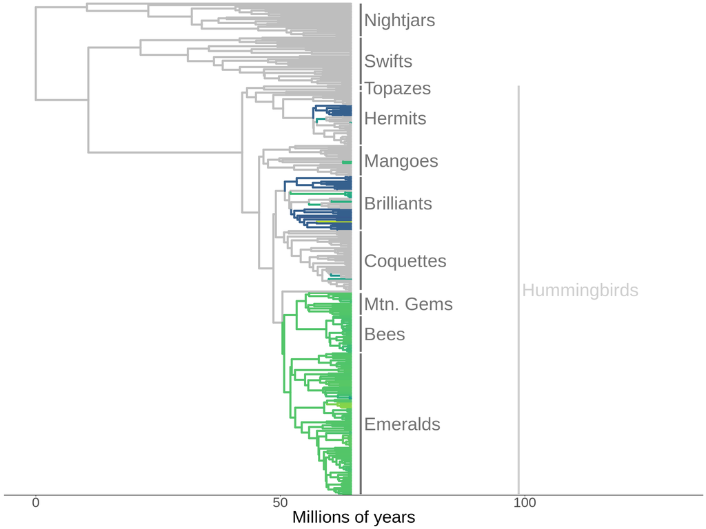

```r
ggtrs$`Sequence complexity`
```

## Acoustic space

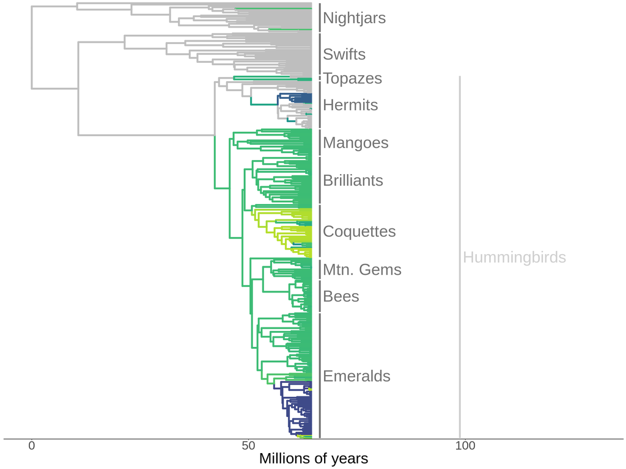

```r
ggtrs$`Acoustic space`
```

## Between song variation

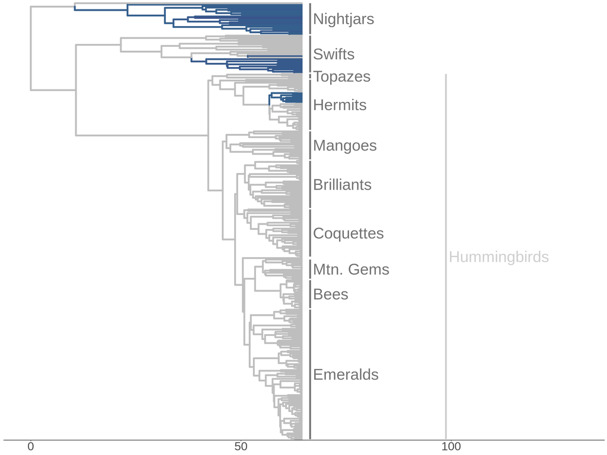

```r
ggtrs$`Between song variation`
```

## Number of element types per song

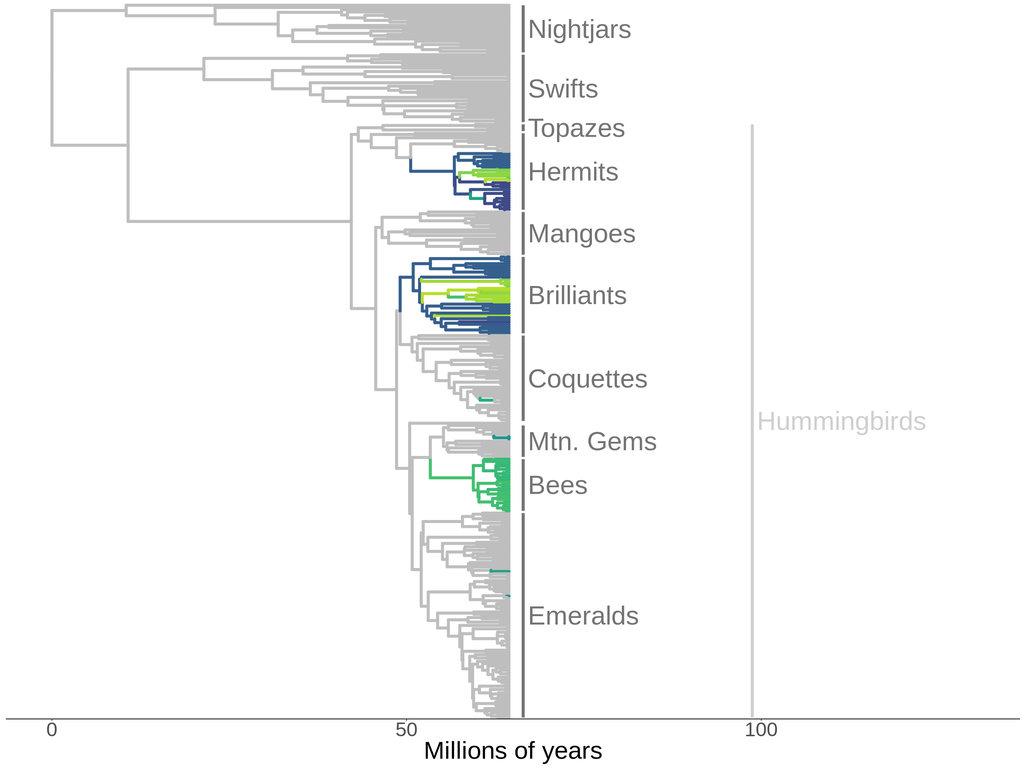

```r
ggtrs$`# of element types`
```

- Evolutionary rate more heterogeneous in hummingbirds, and close to background brownian motion rate in outgroups except for “Between song variation” that evolved slower mostly in outgroups and a bit in hermits
- Hermits (or a groups within hermits) tend to evolve slower in all four parameters
- Acoustic space shows the highest contrasts between hummingbirds and the two outgroups
- Overall complexity in bee hummingbirds has evolved faster than in other hummingbirds except between song variation

# Posterior evolutionary rates per clade

```r
# read branchwise rates
trees <- list.files(path = "./output/bayestraits", full.names = TRUE, pattern = "\\.trees$")

rate.trees <- lapply(trees, read.nexus)

names(rate.trees) <- c("Acoustic space", "Between song variation", "Sequence complexity", "# of element types")

# get mean posterior rates per parameter
post_rates_l <- pblapply(1:length(trees), cl = detectCores() - 1, function(y){

  # extract 1 multiphylo with branch length representing amount of change
  rate.tree <- rate.trees[[y]]

  # get unstransformed tree edge lengths
 if (names(rate.trees)[y] != "Between song variation")
  edge_tab <- get_edge_table(phy) else
    edge_tab <- get_edge_table(phy.btw.sng.vr)
    # edge_tab1 <- get_edge_table(drop.tip(phy, tip = setdiff(phy$tip.label, rate.tree[[1]]$tip.label)))

  node.list <- if(names(rate.trees)[y] != "Between song variation") all.nodes else all.nodes.bsv

  # loop over each sub tree to get rates for each branch x tree
  rates <- lapply(rate.tree, function(z){

    # edge tab for transformed
    edge_tab_rates <- get_edge_table(z)

    # change rate column name
    names(edge_tab_rates)[5] <- "rate.length"

    # merge unstransformed and transformed
    mrg_edge_tab <- merge(edge_tab, edge_tab_rates[, c("parent", "child", "rate.length")])

    # calculate rate
    mrg_edge_tab$rate <- mrg_edge_tab$rate.length / mrg_edge_tab$length

    })

  # put results in a  matrix
  rate.mat <- do.call(cbind, rates)

  # make temporary edge table to get parent numbers
  mrg_edge_tab_temp <- merge(edge_tab, get_edge_table(rate.tree[[1]])[, c("parent", "child", "chi.name")])

  # include parent label
  rate.mat <- cbind(mrg_edge_tab_temp$parent, rate.mat)

  # get mean rate across trees for each clade
  rates.by.clade <- lapply(1:length(node.list), function(w)
    data.frame(clade = names(node.list)[w], rate = apply(rate.mat[rate.mat[,1] %in% node.list[[w]], ], 2, mean)))

  rates.by.clade.df <- do.call(rbind, rates.by.clade)

  rates.by.clade.df$variable <- names(rate.trees)[y]

  return(rates.by.clade.df)
  })

# put all together in a single data frame
post_rates <- do.call(rbind, post_rates_l)

post_rates$log.rate <- log(post_rates$rate + 1)

# save as RDS
saveRDS(post_rates, "./data/processed/posterior_evolutionary_rates_per_clade.RDS")
```

```r
# read branchwise rates
trees <- list.files(path = "./output/bayestraits", full.names = TRUE, pattern = "\\.trees$")

rate.trees <- lapply(trees, read.nexus)

names(rate.trees) <-  c("Acoustic space", "Between song variation", "Sequence complexity", "# of element types")

# get mean posterior rates per parameter
post_rates_l <- pblapply(1:length(trees), cl = detectCores() - 1, function(y){

  # extract 1 multiphylo with branch length representing amount of change
  rate.tree <- rate.trees[[y]]

  # get unstransformed tree edge lengths
 if (names(rate.trees)[y] != "Between song variation")
  edge_tab <- get_edge_table(phy) else
    edge_tab <- get_edge_table(phy.btw.sng.vr)

  node.list <- if(names(rate.trees)[y] != "Between song variation") maj.3.nodes else maj.3.nodes.bsv

  # loop over each sub tree to get rates for each branch x tree
  rates <- lapply(rate.tree, function(z){

    # edge tab for transformed
    edge_tab_rates <- get_edge_table(z)

    # change rate column name
    names(edge_tab_rates)[5] <- "rate.length"

    # merge unstransformed and transformed
    mrg_edge_tab <- merge(edge_tab, edge_tab_rates[, c("parent", "child", "rate.length")])

    # calculate rate
    mrg_edge_tab$rate <- mrg_edge_tab$rate.length / mrg_edge_tab$length
    })

  # put results in a  matrix
  rate.mat <- do.call(cbind, rates)

   # make temporary edge table to get parent numbers
  mrg_edge_tab_temp <- merge(edge_tab, get_edge_table(rate.tree[[1]])[, c("parent", "child", "chi.name")])

  # include parent label
  rate.mat <- cbind(mrg_edge_tab_temp$parent, rate.mat)

  # get mean rate across trees for each clade
  rates.by.clade <- lapply(1:length(node.list), function(w)
    data.frame(clade = names(node.list)[w], rate = apply(rate.mat[rate.mat[,1] %in% node.list[[w]], ], 2, mean)))

  rates.by.clade.df <- do.call(rbind, rates.by.clade)

  rates.by.clade.df$variable <- names(rate.trees)[y]

  return(rates.by.clade.df)
  })

# put all together in a single data frame
post_rates <- do.call(rbind, post_rates_l)

post_rates$log.rate <- log(post_rates$rate + 1)

# save as RDS
saveRDS(post_rates, "./data/processed/posterior_evolutionary_rates_per_clade_3_major_clades.RDS")
```

```r
post_rates <- readRDS("./data/processed/posterior_evolutionary_rates_per_clade.RDS")

  post_rates$maj.clade <- ifelse(post_rates$clade %in% c("Swifts", "Nightjars"), post_rates$clade, "Hummingbirds")

post_rates_3_clades <- readRDS("./data/processed/posterior_evolutionary_rates_per_clade_3_major_clades.RDS")


# for plot have clade as species
post_rates_3_clades$species <- post_rates_3_clades$clade
post_rates$species <- post_rates$clade

gg.rates <- lapply(unique(post_rates$variable), function(w){

  # all clades
  gg.post.rate <- gg.all.clade.collapse.tree

  # get data subset
  dat <- post_rates[post_rates$variable == w, ]

  # keep only data within 95% quantile
  dat.l <- lapply(unique(dat$clade), function(x){

    X <- dat[dat$clade == x, ]
  # if (x != "Nightjars")
  # {
    Z <- X$log.rate
    class(Z) <- "mcmc"
    hpd <- HPDinterval(Z)
    Y <- X[X$log.rate > hpd[1] & X$log.rate < hpd[2], ]
  # }
  # else Y <- X
  #
  return(Y)

        # if (x == "Nightjars" & X$variable[1] == "Between song variation") return(X) else
    })


  dat <- do.call(rbind, dat.l)

  # add facet violin
  gg.post.rate <- facet_plot(gg.post.rate, data = dat, geom = geom_violin, aes(x= log.rate, group = label, fill = maj.clade), panel = paste("Log", w, "rates")) +
      scale_fill_manual(values = cols[c(5, 3, 8)]) +
    theme(legend.position = "none") + geom_vline(xintercept = log_background_rates[w], lty = 2, size = 1.5, col = c("transparent", "black"))


   # 3 major clades
  gg.post.rate.3.maj.clades <- gg.major.clade.collapse.tree

  # get data subset
  dat <- post_rates_3_clades[post_rates_3_clades$variable == w, ]

  # keep only data within 95% quantile
  dat.l <- lapply(unique(dat$clade), function(x){

    X <- dat[dat$clade == x, ]

    try(Y <- X[X$log.rate > quantile(X$log.rate, 0.025) & X$log.rate < quantile(X$log.rate, 0.975), ], silent = TRUE)

        if (x == "Nightjars" & X$variable[1] == "Between song variation") return(X) else
    return(Y)
    })


  dat <- do.call(rbind, dat.l)

  # add facet violin
  gg.post.rate.3.maj.clades <- facet_plot(gg.post.rate.3.maj.clades, data = dat, geom = geom_violin, aes(x= log.rate, group = label, fill = label), panel = paste("Log", w, "rates"))  +
        scale_fill_manual(values = cols[c(8, 3, 5)]) +
    theme(legend.position = "none") +
    geom_vline(xintercept = log_background_rates[w], lty = 2, size = 1.5,  col = c("transparent", "black"))


 # # plot both together
  cow_plt <- plot_grid(gg.post.rate.3.maj.clades, gg.post.rate, ncol = 2)

  return(cow_plt)
  })

names(gg.rates) <- unique(post_rates$variable)
```

## Sequence complexity

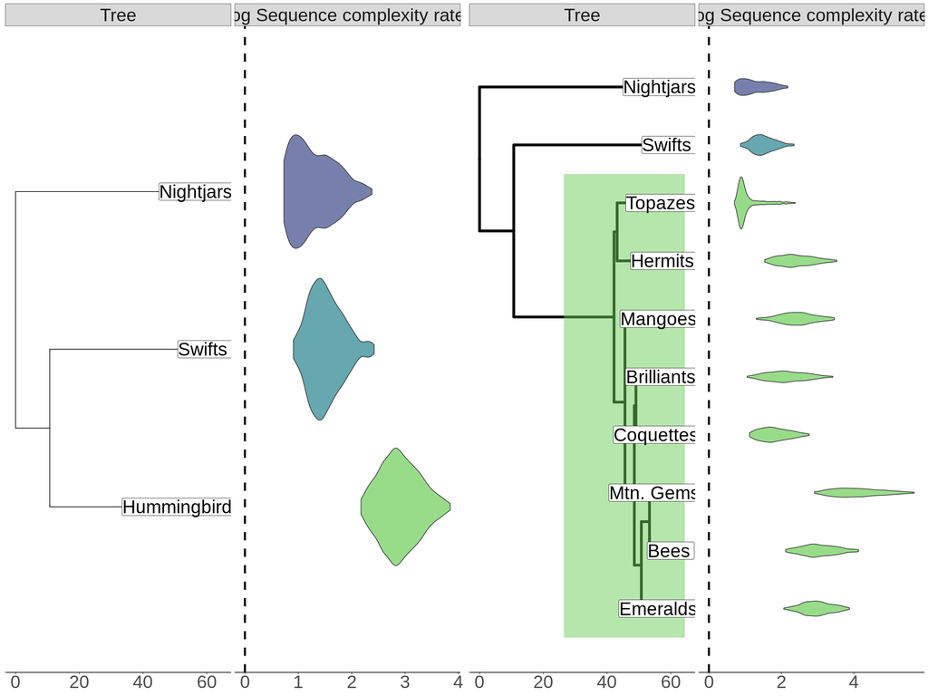

```r
gg.rates$`Sequence complexity`
```

## Acoustic space

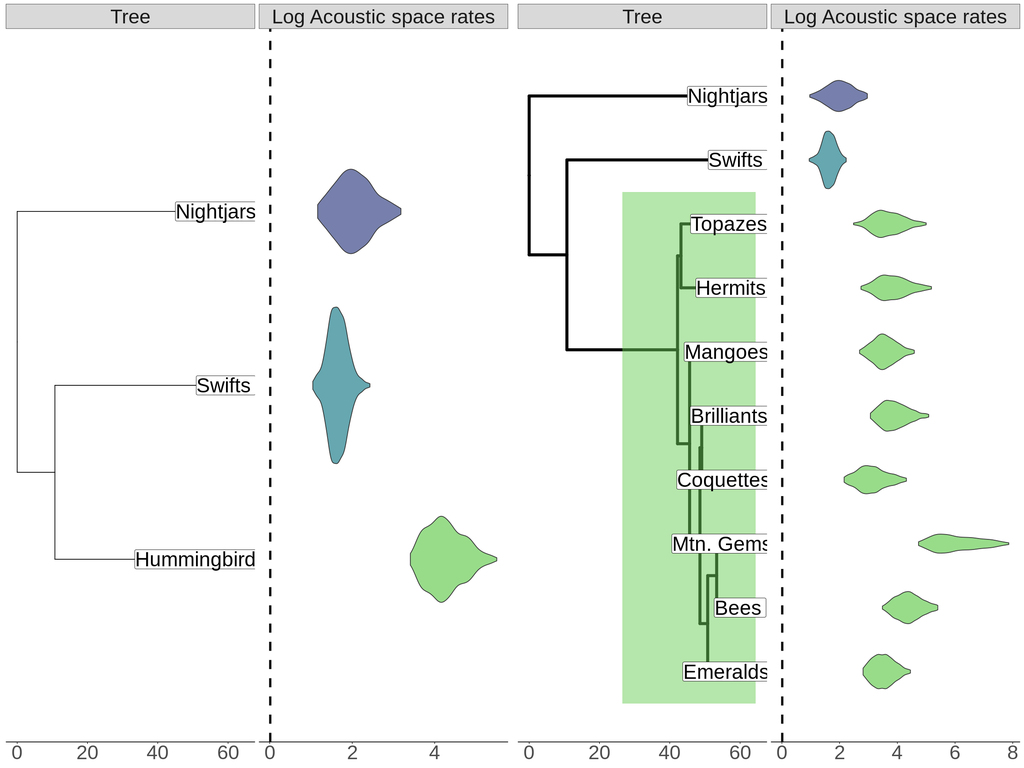

```r
gg.rates$`Acoustic space`
```

## Between song variation

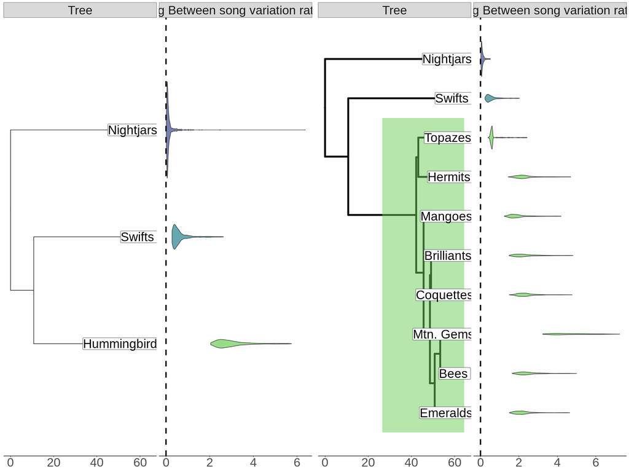

```r
gg.rates$`Between song variation`
```

## Number of elements types per song

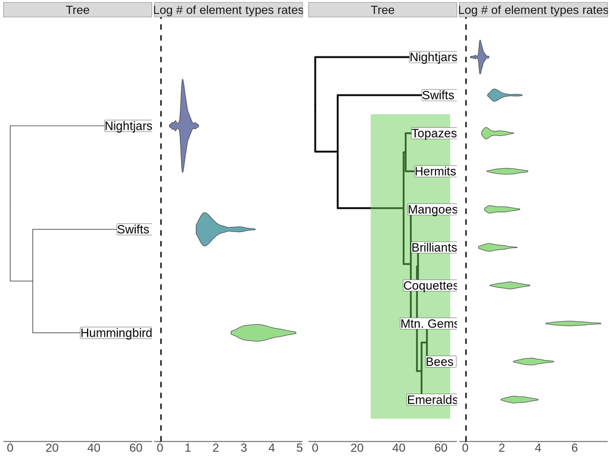

```r
gg.rates$`# of element types`
```

- Overall, evolutionary rates tend to be higher in hummingbirds, with some important differences between hummingbird sub-clades
- Mountain gems show the highest evolutionary rates among all clades
- Nightjars and swifts very similar except for “number of element types”

# Posterior evolutionary correlation between complexity parameters

As a metric of phenotypic integration

(should we use phylogenetically control regressions?)

```r
# proof of concept that trimming file share node labels
# ac_sp_tr <- rate.trees$`Acoustic space`[[1]]
#
# btwn_tr <- rate.trees$`Between song variation`[[1]]
#
# prn_ac_sp_tr <- drop.tip(ac_sp_tr, tip = setdiff(ac_sp_tr$tip.label, btwn_tr$tip.label))
#
# jpeg("trim_phylo.jpeg", width = 1000, height = 5000, pointsize = 20)
#   par(mar = rep(0, 4), mfrow = c(1, 2))
#   plot.phylo(btwn_tr, show.tip.label = FALSE, use.edge.length = FALSE)
#   nodelabels()
#
#   plot.phylo(prn_ac_sp_tr, show.tip.label = FALSE, use.edge.length = FALSE)
#   nodelabels()
#   dev.off()



# read branchwise rates
trees <- list.files(path = "./output/bayestraits", full.names = TRUE, pattern = "\\.trees$")

rate.trees <- lapply(trees, read.nexus)

names(rate.trees) <-  c("Acoustic space", "Between song variation", "Sequence complexity", "# of element types")

rate.trees <- rate.trees[c(1, 3, 4, 2)]

# make combinations of 2 parameters at the time
grd_trees <- t(combn(names(rate.trees), 2))

# get get correlation between complexity
evo_cors_l <- pblapply(1:nrow(grd_trees), cl = detectCores() - 1, function(y){

  # extract 1 bayes traits multiphylo with branch length representing amount of change
  bt_tr1 <- rate.trees[[grd_trees[y, 1]]]
  bt_tr2 <- rate.trees[[grd_trees[y, 2]]]

    # prune tree if different ntips
 if (Ntip(bt_tr1[[1]]) != Ntip(bt_tr2[[1]]))
  {
    bt_tr1 <- lapply(bt_tr1, drop.tip, tip = setdiff(bt_tr1[[1]]$tip.label, bt_tr2[[1]]$tip.label))

  # get node list depending on number of species
    node.list <- all.nodes.bsv

     # get unstransformed tree edge lengths
    edge_tab <- get_edge_table(phy.btw.sng.vr)
    # edge_tab <- get_edge_table(drop.tip(phy, tip = setdiff(phy$tip.label, phy.btw.sng.vr$tip.label)))

    } else { # if both trees have 318 species
     # get unstransformed tree edge lengths
    edge_tab <- get_edge_table(phy)

    # node list
   node.list <- all.nodes
    }

  # make edge rate table template
  edge_tab_templ <- get_edge_table(bt_tr1[[1]])

  # change rate column name
  names(edge_tab_templ)[5] <- "delete"

  # merge unstransformed and transformed
  edge_tab_templ <- merge(edge_tab, edge_tab_templ[, c("parent", "child", "delete")])

  edge_tab_templ$delete <- NULL

  # loop over each sub tree to get rates for each branch x tree
  rates_tr1 <- sapply(bt_tr1, function(z){

  # edge tab for transformed
  edge_tab_rates <- get_edge_table(z)

  # change rate column name
  names(edge_tab_rates)[5] <- "rate.length"

  # merge unstransformed and transformed
  mrg_edge_tab <- merge(edge_tab_templ, edge_tab_rates[, c("parent", "child", "rate.length")])

  # calculate rate
  mrg_edge_tab$rate <- mrg_edge_tab$rate.length / mrg_edge_tab$length

  return(mrg_edge_tab$rate)
  })

  # rates second tree
  rates_tr2 <- sapply(bt_tr2, function(z){

  # edge tab for transformed
  edge_tab_rates <- get_edge_table(z)

  # change rate column name
  names(edge_tab_rates)[5] <- "rate.length"

  # merge unstransformed and transformed
  mrg_edge_tab <- merge(edge_tab_templ, edge_tab_rates[, c("parent", "child", "rate.length")])

  # calculate rate
  mrg_edge_tab$rate <- mrg_edge_tab$rate.length / mrg_edge_tab$length

  return(mrg_edge_tab$rate)
  })

 # sample 1000 tree values randomly for each tree
 # ang get correlation of log rates
  cors_clade_l <- lapply(1:length(node.list), function(w)
  {

    # select rates for each clade based on nodes
    rt1 <- rates_tr1[edge_tab_templ$parent %in% node.list[[w]], ]
    rt2 <- rates_tr2[edge_tab_templ$parent %in% node.list[[w]], ]

    cors <- sapply(1:10000, function(x)
     cor(log(rt1[, sample(1:ncol(rt1), 1), drop = TRUE] + 1), log(rt2[, sample(1:ncol(rt2), 1), drop = TRUE] + 1))
       )

    return(data.frame(clade = names(node.list)[w], cor = cors))
    })

  cors_clade <- do.call(rbind, cors_clade_l)

  # names(cors_clade) <- names(node.list)

  cors_df <- data.frame(clade = cors_clade$clade, param1 = grd_trees[y, 1], param2 = grd_trees[y, 2], cor = cors_clade$cor)

  return(cors_df)
  })

# put all together in a single data frame
evo_cors <- do.call(rbind, evo_cors_l)


# save as RDS
saveRDS(evo_cors, "./data/processed/posterior_evolutionary_rate_correlations.RDS")
```

```r
evo_cors <- readRDS("./data/processed/posterior_evolutionary_rate_correlations.RDS")

evo_cors$variable.pair <- paste0(evo_cors$param1, "-", evo_cors$param2)

evo_cors_3_clades <- evo_cors[evo_cors$clade %in% c("Nightjars", "Swifts", "Hummingbirds"), ]

# remove hummingbirds
evo_cors <- evo_cors[evo_cors$clade != "Hummingbirds", ]

# for plot have clade as species
evo_cors_3_clades$species <- as.character(evo_cors_3_clades$clade)
evo_cors$species <- as.character(evo_cors$clade)

evo_cors$maj.clade <- as.character(ifelse(evo_cors$species %in% c("Nightjars", "Swifts"), evo_cors$species, "Hummingbirds"))


gg_cor_rates <- lapply(c(unique(evo_cors$variable.pair), "overall"), function(w){

  # all clades
  gg.cor.rate <- gg.all.clade.collapse.tree +
    geom_vline(xintercept = 0, lty = 2, size = 1.5,  col = c("transparent", "black"))

  # get data subset
  if (w != "overall")
  dat <- evo_cors[evo_cors$variable.pair == w, ] else
    dat <- evo_cors

  # keep only data within 95% quantile
  dat.l <- lapply(unique(dat$species), function(x){

    X <- dat[dat$species == x, ]
    Z <- X$cor
  class(Z) <- "mcmc"
  hpd <- HPDinterval(Z)

  Y <- X[X$cor > hpd[1] & X$cor < hpd[2], ]
  return(Y)
    })

  dat <- do.call(rbind, dat.l)

  # add facet violin
  gg.cor.rate <- facet_plot(gg.cor.rate, data = dat, geom = geom_violin, aes(x= cor, group = label, fill = maj.clade), panel = w) +
      scale_fill_manual(values = cols[c(8, 3, 5)]) +
    theme(legend.position = "none")


   # 3 major clades
  gg.cor.rate.3.maj.clades <- gg.major.clade.collapse.tree + geom_vline(xintercept = 0, lty = 2, size = 1.5, col = c("transparent", "black"))

  # get data subset
    if (w != "overall")
  dat <- evo_cors_3_clades[evo_cors_3_clades$variable.pair == w, ] else
    dat <- evo_cors_3_clades

  # keep only data within 95% quantile
  dat.l <- lapply(unique(dat$clade), function(x){

      X <- dat[dat$clade == x, ]
      Z <- X$cor
      class(Z) <- "mcmc"
      hpd <- HPDinterval(Z)
      Y <- X[X$cor > hpd[1] & X$cor < hpd[2], ]
      return(Y)
        })


  dat <- do.call(rbind, dat.l)

  # add facet violin
  gg.cor.rate.3.maj.clades <-
    facet_plot(gg.cor.rate.3.maj.clades, data = dat, geom = geom_violin, aes(x= cor, group = label, fill = label), panel = w)  +
        scale_fill_manual(values = cols[c(8, 3, 5)]) +
    theme(legend.position = "none")

 # # plot both together
  cow_plt <- plot_grid(gg.cor.rate.3.maj.clades, gg.cor.rate, ncol = 2)

  return(cow_plt)
  })

names(gg_cor_rates) <- c(unique(evo_cors$variable.pair), "overall")
```

## Acoustic space vs Sequence complexity

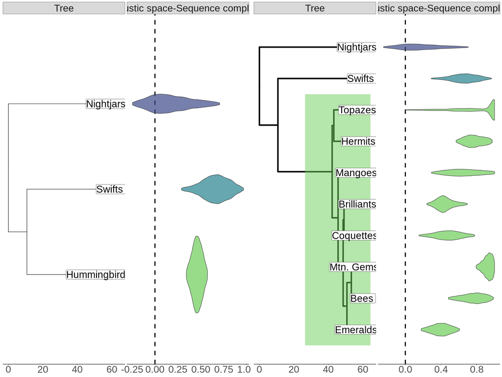

```r
gg_cor_rates$`Acoustic space-Sequence complexity`
```

## Acoustic space vs Number of element types

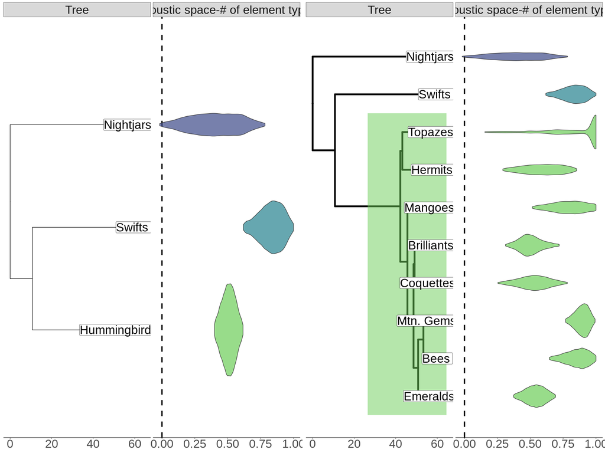

```r
gg_cor_rates$`Acoustic space-# of element types`
```

## Acoustic space vs Between song variation

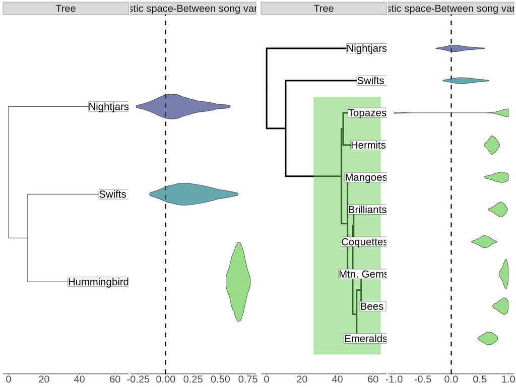

```r
gg_cor_rates$`Acoustic space-Between song variation`
```

## Sequence complexity vs Number of element types

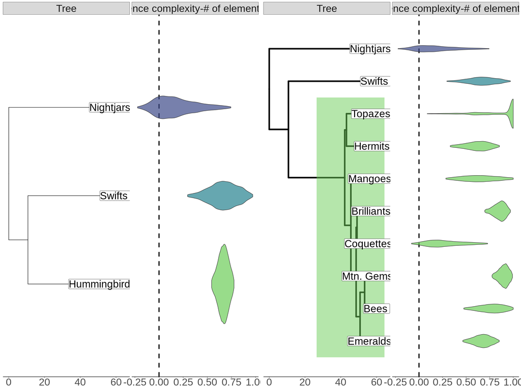

```r
gg_cor_rates$`Sequence complexity-# of element types`
```

## Sequence complexity vs Between song variation

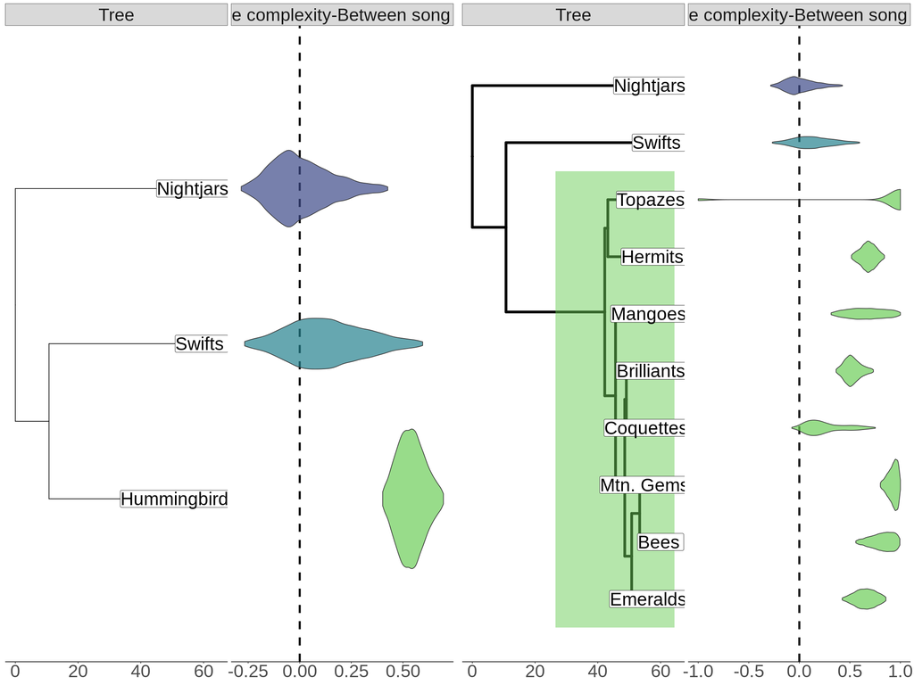

```r
gg_cor_rates$`Sequence complexity-Between song variation`
```

## Number of element types vs Between song variation

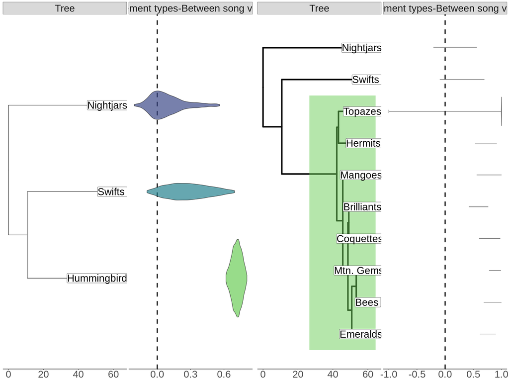

```r
gg_cor_rates$`# of element types-Between song variation`
```

## Overall correlation between evolutionary rates of all 4 complexity parameters

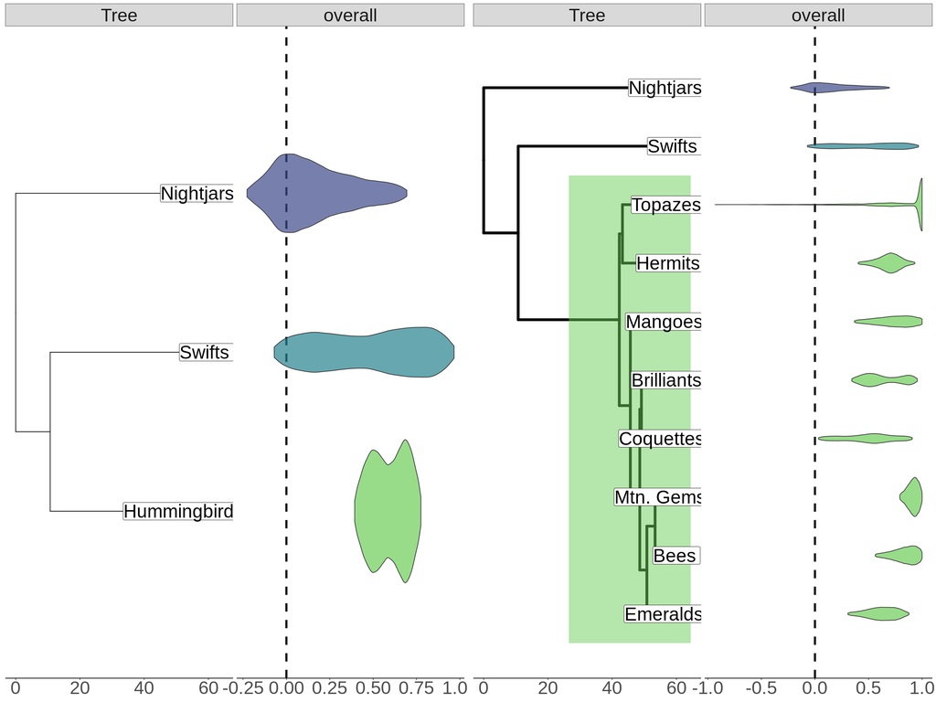

```r
gg_cor_rates$overall
```

- Nightjars show low integration across all parameter pairs
- Hummingbirds and swifts show similar levels of integration and higher than nightjars
- However, only hummingbirds show “significant” integration (always higher than 0) for all pairwise comparisons as well as overall integration